# Analiza procesu zmniejszania się długości śledzi oceanicznych wyławianych w Europie

Michał Kuźma

01 grudzień, 2016

# 1 Streszczenie wyników analizy

Dane przedstawiają zmniejszającą się w czasie długość łowionych śledzi w Europie. Po wyczyszczeniu danych i przeprowadzeniu analizy zauważono silny wpływ temperatury przy powierzchni wody na rozmiar łowionego śledzia (im wyższa temperatura, tym mniejszy śledź). Słabsze pozytywne korelacje zauważono w stosunku do atrybutów opisujących zagęszczenie widłogonów i planktonu *Calanus helgolandicus gatunku pierwszego*, oraz ułamek pozostawionego w regionie narybku. Oscylacja północnoatlantycka zdaje się negatywnie wpływać na rozmiary łowionych śledzi (im większa wartość oscylacji, tym mniejsza ryba).

# 2 Biblioteki wykorzystane do wygenerowania raportu

Do wygenerowania raportu wykorzystano następujące biblioteki:

```r
# Pisanie sprawozdania
library(knitr)
# Analiza danych
library(plyr)
library(dplyr)
# Porządkowanie danych
library(tidyr)
# Wykresy
library(ggplot2)
library(plotly)
library(GGally)
# Macierz korelacji
library(corrplot)
# Regresja
library(caret)
```

# 3 Wczytywanie danych z pliku

```r
# Ustawienie ziarna zapewnia powtarzalność wyników
set.seed(23)

sledzie <- read.csv("sledzie.csv", comment.char = "",
                    na.strings = "?",
                    col.names = c("id", "length", "cfin1", "cfin2", "chel1", "chel2", "lcop1", "lcop2", "fbar", "recr", "cumf", "totaln", "sst", "sal", "xmonth", "nao"))
```

# 4 Przetwarzanie brakujących danych

W pierwszej kolejności przeprowadzono analizę danych mającą na celu oszacowanie ich “czystości, a więc liczby pól o nieznanej wartości (NA). Poniżej znajduje się podsumowanie liczby brakujących wartości we wczytanych danych (kolumny bez brakujących wartości nie zostały uwzględnione na wykresie).

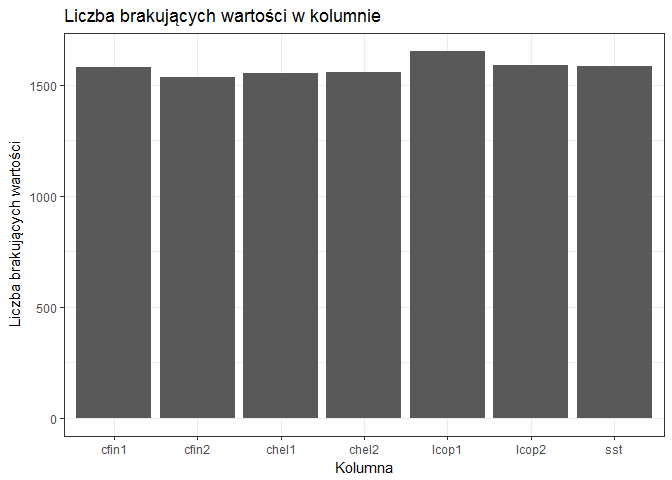

```r
impute.mean <- function(x) replace(x, is.na(x), mean(x, na.rm = TRUE))
data <- ddply(sledzie, .(totaln), transform,
                       cfin1 = impute.mean(cfin1),
                       cfin2 = impute.mean(cfin2),
                       chel1 = impute.mean(chel1),
                       chel2 = impute.mean(chel2),
                       lcop1 = impute.mean(lcop1),
                       lcop2 = impute.mean(lcop2),
                       sst = impute.mean(sst))
```

# 5 Podsumowanie danych

Oczyszczony zbiór danych składa się z 52582 obserwacji opisanych przez 16 atrybutów. Jego statystyki zamieszczono poniżej.

|  | id | length | cfin1 | cfin2 | chel1 | chel2 | lcop1 | lcop2 |
| --- | --- | --- | --- | --- | --- | --- | --- | --- |
|  | Min. : 0 | Min. :19.0 | Min. : 0.0000 | Min. : 0.0000 | Min. : 0.000 | Min. : 5.238 | Min. : 0.3074 | Min. : 7.849 |
|  | 1st Qu.:13145 | 1st Qu.:24.0 | 1st Qu.: 0.0000 | 1st Qu.: 0.2778 | 1st Qu.: 2.469 | 1st Qu.:13.427 | 1st Qu.: 2.5479 | 1st Qu.:17.808 |
|  | Median :26291 | Median :25.5 | Median : 0.1111 | Median : 0.7012 | Median : 5.750 | Median :21.435 | Median : 7.0717 | Median :24.859 |
|  | Mean :26291 | Mean :25.3 | Mean : 0.4462 | Mean : 2.0258 | Mean :10.003 | Mean :21.219 | Mean : 12.8080 | Mean :28.422 |
|  | 3rd Qu.:39436 | 3rd Qu.:26.5 | 3rd Qu.: 0.3333 | 3rd Qu.: 1.7936 | 3rd Qu.:11.500 | 3rd Qu.:27.193 | 3rd Qu.: 21.2315 | 3rd Qu.:37.232 |
|  | Max. :52581 | Max. :32.5 | Max. :37.6667 | Max. :19.3958 | Max. :75.000 | Max. :57.706 | Max. :115.5833 | Max. :68.736 |

|  | fbar | recr | cumf | totaln | sst | sal | xmonth | nao |
| --- | --- | --- | --- | --- | --- | --- | --- | --- |
|  | Min. :0.0680 | Min. : 140515 | Min. :0.06833 | Min. : 144137 | Min. :12.77 | Min. :35.40 | Min. : 1.000 | Min. :-4.89000 |
|  | 1st Qu.:0.2270 | 1st Qu.: 360061 | 1st Qu.:0.14809 | 1st Qu.: 306068 | 1st Qu.:13.60 | 1st Qu.:35.51 | 1st Qu.: 5.000 | 1st Qu.:-1.89000 |
|  | Median :0.3320 | Median : 421391 | Median :0.23191 | Median : 539558 | Median :13.86 | Median :35.51 | Median : 8.000 | Median : 0.20000 |
|  | Mean :0.3304 | Mean : 520367 | Mean :0.22981 | Mean : 514973 | Mean :13.87 | Mean :35.51 | Mean : 7.258 | Mean :-0.09236 |
|  | 3rd Qu.:0.4560 | 3rd Qu.: 724151 | 3rd Qu.:0.29803 | 3rd Qu.: 730351 | 3rd Qu.:14.16 | 3rd Qu.:35.52 | 3rd Qu.: 9.000 | 3rd Qu.: 1.63000 |
|  | Max. :0.8490 | Max. :1565890 | Max. :0.39801 | Max. :1015595 | Max. :14.73 | Max. :35.61 | Max. :12.000 | Max. : 5.08000 |

Dla każdego atrybutu stworzono wykres obrazujący, jakie wartości przyjmował na przestrzeni kolejnych połowów.

Dostępność wszystkich sześciu gatunków planktonu zobrazowano na jednym wykresie, aby ułatwić zaobserwowanie korelacji pomiędzy atrybutami.

[interactive chart not shown]

# 6 Analiza korelacji między atrybutami

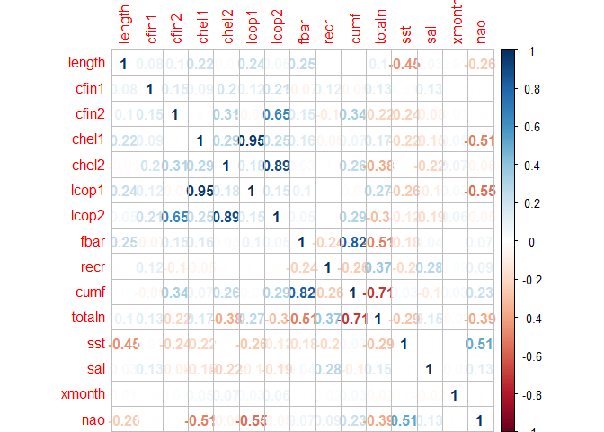

Współczynniki korelacji potwierdzają zaobserwowaną wcześniej zależność między parami parametrów *lcop1* i *chel1* oraz *lcop2* i *chel2*. Ze zbioru danych usunięto parametry *chel1* i *chel2*, z powodu zaobserwowanej korelacji.

Po zakończonej analizie i wykluczeniu ze zbioru danych parametrów skorelowanych z innymi, obserwacje opisane są 13 parametrami.

Do oszacowania długości śledzia istotny wydaje się być atrybut *sst* (znaczna ujemna korelacja), oraz w mniejszym stopniu atrybuty *lcop1*, *fbar* i *nao*.

# 7 Zmiana rozmiaru śledzia w czasie

[interactive chart not shown]

# 8 Regresor przewidujący rozmiar śledzia

Zbiór danych został podzielony na dane uczące, walidujące i testowe w proporcjach 14:3:3.

Stworzono regresor przewidujący długość złowionego śledzia na podstawie pozostałych parametrów. Trafność regresora:

| mtry | RMSE | Rsquared | RMSESD | RsquaredSD |
| --- | --- | --- | --- | --- |
| 2 | 1.168707 | 0.4982295 | 0.0049308 | 0.0028558 |
| 6 | 1.150110 | 0.5140356 | 0.0052672 | 0.0029252 |
| 11 | 1.150454 | 0.5144003 | 0.0056334 | 0.0032909 |

Przewidziane rozmiary śledzi dla zbioru testowego przedstawiono na poniższych wykresach.

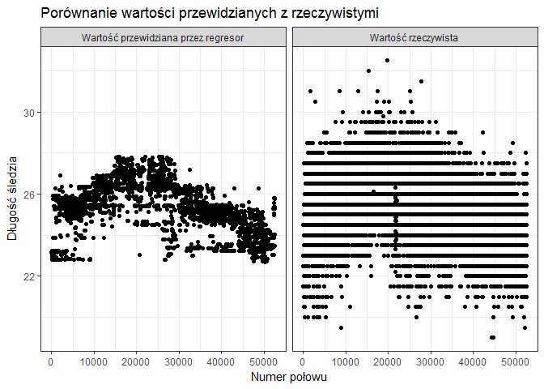

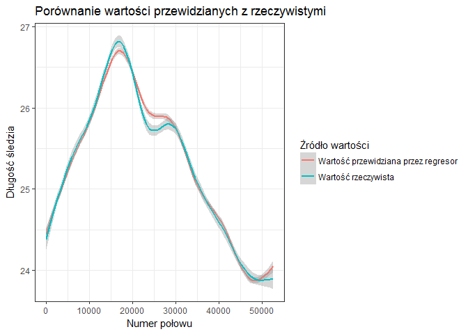